# Spatial dependency in INLA

So far we have completely ignored the spatial structure in our data, but this is bad. Sites that are close to eachother may just be more similar (Toblers law;especially for an environmental pathogen like BU)

```
bounding box given to google - spatial extent only approximate.converting bounding box to center/zoom specification. (experimental)
```

[figure not shown]

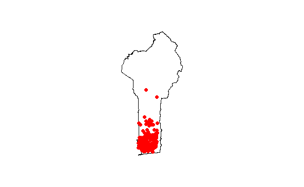

If you are not online you can use the bottom option for a plain outline rather than the ggmap approach.

# Spatial dependency

Do we have spatial dependency in our dataset?

Either we can test the residuals of our last model (eg the binomial one) and can see if there is a pattern in them OR we can assume from our data that as it is spatial data, our model design should take account of that.

While I am believer of the second option, here is a way of detecting spatial patterns in your residuals

```r
#rerun our binomial model and extract the residuals
f10 <- BU_TOT ~ Forest +  MeanNDVI + MeanTemp + ShrGra
TOT_POP<-bu$TOT_POP #our n trials
I10 <- inla(f10,
           family = "binomial",
           control.compute = list(dic = TRUE, waic = TRUE),
           control.predictor = list(compute = TRUE),
           Ntrials = TOT_POP,
           data = bu)
summary(I10)
```

```
Call:
c("inla(formula = f10, family = \"binomial\", data = bu, Ntrials = TOT_POP, ",  "    control.compute = list(dic = TRUE, waic = TRUE), control.predictor = list(compute = TRUE))" )

Time used:
 Pre-processing    Running inla Post-processing           Total
         7.4154         12.1896          0.8340         20.4391

Fixed effects:
                 mean     sd 0.025quant  0.5quant 0.975quant      mode
(Intercept) -118.0797 4.1055  -126.1415 -118.0794  -110.0270 -118.0785
Forest        -5.6642 1.1533    -7.9801   -5.6464    -3.4475   -5.6106
MeanNDVI       5.8620 1.0621     3.7867    5.8584     7.9550    5.8513
MeanTemp       3.9663 0.1489     3.6740    3.9663     4.2583    3.9663
ShrGra        -1.2656 0.1477    -1.5558   -1.2655    -0.9761   -1.2653
            kld
(Intercept)   0
Forest        0
MeanNDVI      0
MeanTemp      0
ShrGra        0

The model has no random effects

The model has no hyperparameters

Expected number of effective parameters(std dev): 5.00(0.00)
Number of equivalent replicates : 59.00

Deviance Information Criterion (DIC) ...: 2615.32
Effective number of parameters .........: 4.996

Watanabe-Akaike information criterion (WAIC) ...: 2736.53
Effective number of parameters .................: 108.94

Marginal log-Likelihood:  -1322.77
Posterior marginals for linear predictor and fitted values computed
```

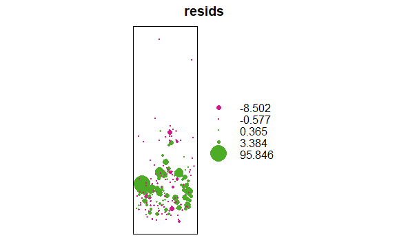

```r
#extract our binomial residuals
Pi   <- I10$summary.fitted.values[,"mean"]
ExpY <- Pi * bu$TOT_POP
VarY <- bu$TOT_POP * Pi * (1 - Pi)
E1   <- (bu$BU_TOT - ExpY) / sqrt(VarY)
#do a bubble plot.
dat<-data.frame(bu$Long,bu$Lat,resids=E1)
coordinates(dat)<-c('bu.Long','bu.Lat')
bubble(dat,zcol='resids')
```

Looks like there is correlation in the bottom left and right where the plots are bigger and green (ie large and positive)

Its also really useful to look at a variogram. Here we use semivariance to assess whether points close to eachother are more likel to be similar than points further away. The direction in which we apply the semivariance may also change our interpretation of spatial correlation

Here we assess spatial correlation in the residuals in a northern, northeastern, eastern and southeastern direction, which will be a mirror of the opposite way.

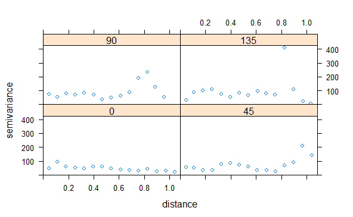

```r
var.mod<-variogram(resids~1,data=dat,alpha=c(0,45,90,135))
plot(var.mod)
```

Variance is strongest in an east west direction, which matches with what we found for our bubble plot

We are not accounting for spatial variation!

Lets do that!

# Steps for fitting spatial dependency

1. Make a mesh 2, Define the weighting parameters (projector matrix A)
2. Define the SPDE
3. Define the spatial field
4. Make a stack
5. Define the model formula
6. Run in INLA
7. Inspect the results

First, we rewrite our model:

BU_TOT_i ~ Bin(P_i,N_i) E(BU_i) = N_i * P_i (Number of trials * probability of event) + u_i  
var(BU_i) = N_i * P_i * (1-P_i)

P_i = exp(Covariates) / 1+exp(Covariates)

where: u_i ~ GMRF(0, sigma^2) (our spatial random effect - G = gaussian)

u_i has mean 0 and variance, sigma, is a covariance matrix

We calculate a spatial random effect, u_i, for each of our observations, via u = w*A. We define w on the mesh, and A is our projector matrix.

Recap on meshes:

We will use the gaussain markovian random field to calculate spatial correlation, but it requires observations on a regular grid. This is rarely the case, so a mesh substitutes for that.

The mesh involves dividing the study area into a large number of overlapping triangles that have one common corner. Where corners join are the vertices. Initially, vertices are placed at the sampling locations, then the user defines where more are placed.

To do this you define the:

loc = coordinates of your observations

max.edge - the largest allowed triangle length (larger the edge length, the lower the accuracy / resolution of the mesh). Can define an inner and an outer region by including a vector of two edge lengths. Good idea to deal with boundary issues - make the outer boundary larger than the inner boundary to reduce computing costs. This is defined through offset.

There are many options - Blangiardo and Cameletti (2015) has nice details about this. For example, including a boundary means that you can use a shapefile to restrict your mesh (ie if you are along a coastline). We wont cover this, but it is possible. Zuur, Saveliev and Ieno 2017 covers this.

1. Define a mesh

```r
#First figure out how far our sites are
Loc <- cbind(bu$X.utm, bu$Y.utm) #use UTM rather than lat long because it is a regular grid
head(Loc)
```

```
         [,1]     [,2]
[1,] 427930.9 705624.9
[2,] 349439.1 753848.7
[3,] 353129.7 756326.3
[4,] 353509.1 771160.1
[5,] 355095.9 768023.1
[6,] 357459.5 768108.4
```

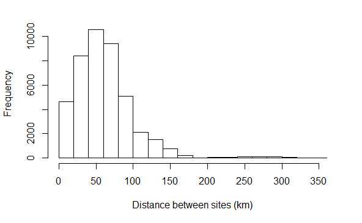

```r
#gives distance in metres
# Distances between sampling locations
D <- dist(Loc)
hist(D / 1000,
     freq = TRUE,
     main = "",
     xlab = "Distance between sites (km)",
     ylab = "Frequency")
```

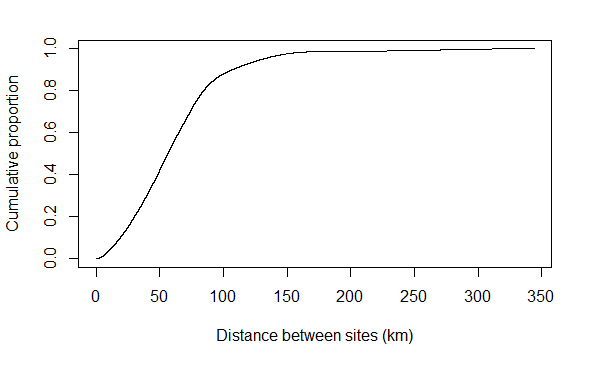

```r
plot(x = sort(D) / 1000,
     y = (1:length(D))/length(D),
     type = "l",
     xlab = "Distance between sites (km)",
     ylab = "Cumulative proportion")
#Lets make a few different meshes
mesh1 <- inla.mesh.2d(Loc, max.edge=c(10, 10) * 1000, cutoff = 0)
mesh2 <- inla.mesh.2d(Loc, max.edge=c(10, 10) * 1000, cutoff = 10 * 1000)
mesh3 <- inla.mesh.2d(Loc, max.edge=c(50, 50) * 1000)
mesh4 <- inla.mesh.2d(Loc, max.edge=c(75, 75) * 1000, cutoff = 1 * 1000)
mesh5 <- inla.mesh.2d(Loc, max.edge=c(25, 50) * 1000, cutoff = 1 * 1000)
mesh6 <- inla.mesh.2d(Loc, max.edge=c(50, 80) * 1000, cutoff = 1 * 1000)
mesh7 <- inla.mesh.2d(Loc, max.edge=c(100, 120) * 1000, cutoff = 1 * 1000)
mesh8 <- inla.mesh.2d(Loc, max.edge=c(150, 150) * 1000, cutoff = 1 * 1000)
Bound <- inla.nonconvex.hull(Loc)
mesh9 <- inla.mesh.2d(boundary = Bound,
                      max.edge = 50 * 1000,
                      cutoff   = 5 * 1000)
# Make a plot of the meshes
par(mfrow=c(3,3), mar=c(1,1,1,1))
```

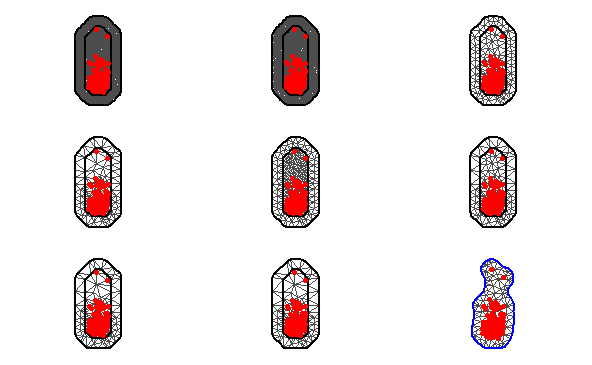

```r
for (i in 1:9){
  plot(get(paste('mesh', i, sep = '')), main = "",asp=1)
  points(Loc, col = 2, pch = 16, cex = 1)
}
```

```r
# Number of vertices:
c(mesh1$n, mesh2$n, mesh3$n, mesh4$n, mesh5$n, mesh6$n,
  mesh7$n, mesh8$n, mesh9$n)
```

```
[1] 3188 2872  742  531  645  536  525  525  121
```

First few are waaay to dense - that would really up your computing time, around 700 ish points is ok. The best one is actually the middle one - the grid inside the boundary is well defined while the outside one has larger triangles. a cutoff of 1k between our sites seems reasonable. Good idea is to test models with a mesh of around 700 n and then do the final model with a mesh of say 3000 n to get a finer predictive surface

We have our mesh. Mesh 5. Next step = projector matrix

```r
A5 <- inla.spde.make.A(mesh5, loc = Loc)
dim(A5)
```

```
[1] 295 645
```

295 locations and 645 vertices

Next step - Define the SPDE

Priors appear again here!

These are penalised complexity priors

ie: prior.range = c(a,b) means P(Range < a)= b

This seems unlikely from what we know, so we should drop that down to a more reasonable distance

prior.sigma is diffuse in this example (.5)

```r
spde5 <- inla.spde2.pcmatern(mesh5, prior.range = c(50 * 1000, 0.05), prior.sigma = c(.5, .5))
```

Next we define the spatial field. Using the index is useful if you are including replicates or groups in your model - best to just do by default

```r
w5.index <- inla.spde.make.index('w', n.spde = spde5$n.spde)
```

Next we define the stack. This is especially useful if you are trying to keep track of more complex models, so although for simple models it is not necessary, it is best to just do by default. again do by default is best. We do this to tell INLA at which sample locations we have data for the response variable and where we have the covariate data, so that we can calculate the posterior mean.

For the binomial model we have an extra variable - the number of trials. We need to include this in the data bit with the response variable

```r
# Make the X matrix (-1 means remove the intercept)
Xm <- model.matrix(~ -1 + Forest + MeanNDVI + MeanTemp + ShrGra,
                   data = bu)
head(Xm)
```

```
  Forest  MeanNDVI MeanTemp ShrGra
1   0.24 0.2209703     27.2   0.06
2   0.02 0.2861486     27.2   0.65
3   0.02 0.2953299     27.0   0.94
4   0.00 0.2542900     26.5   0.96
5   0.00 0.2868261     27.0   0.98
6   0.00 0.1882990     26.7   0.99
```

```r
colnames(Xm)
```

```
[1] "Forest"   "MeanNDVI" "MeanTemp" "ShrGra"
```

```r
# Define sample size
N <- nrow(bu)
# This is the X matrix
X <- data.frame(Forest           = Xm[,1],
                MeanNDVI         = Xm[,2],
                MeanTemp         = Xm[,3],
                ShrGra           = Xm[,4])
head(X)
```

|  | Forest | MeanNDVI | MeanTemp | ShrGra |
| --- | --- | --- | --- | --- |
| 1 | 0.24 | 0.2209703 | 27.2 | 0.06 |
| 2 | 0.02 | 0.2861486 | 27.2 | 0.65 |
| 3 | 0.02 | 0.2953299 | 27.0 | 0.94 |
| 4 | 0.00 | 0.2542900 | 26.5 | 0.96 |
| 5 | 0.00 | 0.2868261 | 27.0 | 0.98 |
| 6 | 0.00 | 0.1882990 | 26.7 | 0.99 |

```r
colnames(X)
```

```
[1] "Forest"   "MeanNDVI" "MeanTemp" "ShrGra"
```

```r
dim(X)
```

```
[1] 295   4
```

```r
StackFit <- inla.stack(
  tag = "Fit",
  data = list(y = bu$BU_TOT, Ntrials = bu$TOT_POP),
  A = list(1, 1, A5),
  effects = list(
    Intercept = rep(1, N), #intercept included to use without covariates so can only see contribution from spatial covariates
    X = X,
    w = w5.index))
```

Where it says A = list(1,1,A5), first 1 refers to the intercept, second 1 refer to the covariates adn the A5 is w

Next we respecify our models with and without th espatial correlation to compare

```r
f11a <- y ~ -1 + Intercept +
  Forest  + MeanNDVI + MeanTemp +
  ShrGra
f11b <- y ~ -1 + Intercept +
  Forest  + MeanNDVI + MeanTemp +
  ShrGra +
  f(w, model = spde5) #plus spatial correlation - we put in the ws and tell it which model
```

Finally, we run the model

```r
I11a <- inla(f11a,
             family = "binomial",
             data = inla.stack.data(StackFit),
             control.compute = list(dic = TRUE),
             control.predictor = list(A = inla.stack.A(StackFit)),
             Ntrials = Ntrials)
summary(I11a)
```

```
Call:
c("inla(formula = f11a, family = \"binomial\", data = inla.stack.data(StackFit), ",  "    Ntrials = Ntrials, control.compute = list(dic = TRUE), control.predictor = list(A = inla.stack.A(StackFit)))" )

Time used:
 Pre-processing    Running inla Post-processing           Total
         4.1862          3.3574          0.7667          8.3103

Fixed effects:
               mean     sd 0.025quant  0.5quant 0.975quant      mode
Intercept -116.1178 4.0724  -124.1101 -116.1191  -108.1259 -116.1213
Forest      -5.6122 1.1509    -7.9306   -5.5918    -3.4072   -5.5507
MeanNDVI     5.7863 1.0654     3.7048    5.7827     7.8860    5.7756
MeanTemp     3.8954 0.1477     3.6053    3.8955     4.1850    3.8956
ShrGra      -1.2485 0.1476    -1.5386   -1.2485    -0.9593   -1.2483
          kld
Intercept   0
Forest      0
MeanNDVI    0
MeanTemp    0
ShrGra      0

The model has no random effects

The model has no hyperparameters

Expected number of effective parameters(std dev): 4.987(0.00)
Number of equivalent replicates : 59.16

Deviance Information Criterion (DIC) ...: 2615.34
Effective number of parameters .........: 4.981

Marginal log-Likelihood:  -1333.96
Posterior marginals for linear predictor and fitted values computed
```

```r
# And this is the model with the spatial field
I11b <- inla(f11b,
             family = "binomial",
             data=inla.stack.data(StackFit),
             control.compute = list(dic = TRUE),
             control.predictor = list(A = inla.stack.A(StackFit)),
             Ntrials = Ntrials)
# Compare them
c(I11a$dic$dic, I11b$dic$dic)
```

```
[1] 2615.343 1056.615
```

But - what an improvement in the DIC. Including the spatial variation is important!

Lets do a coef plot of both of them

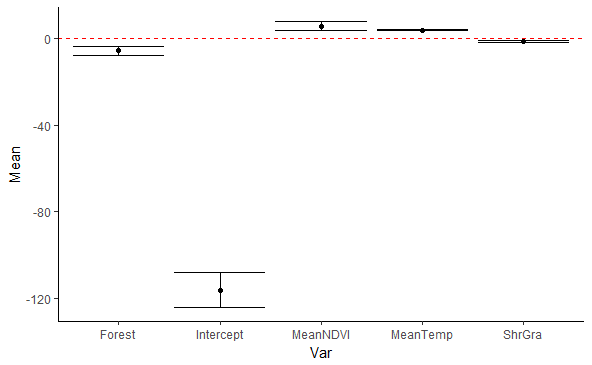

```r
#helper function for plot
coefplot.inla<-function(model){
  betas<-model["summary.fixed"]
  round(betas$summary.fixed[, c("mean","0.025quant","0.975quant")],3)->betas
betas$Var <- rownames(betas)
names(betas)<-c("Mean", "LowQ", "HiQ", "Var")
p<-ggplot(betas)+geom_point(aes(Var, Mean))+geom_errorbar(aes(x = Var, ymax =  HiQ, ymin =  LowQ))+geom_hline(aes(yintercept = 0), col = 2, linetype = "dashed")+theme_classic()
return(p)
}
coefplot.inla(I11a)
```

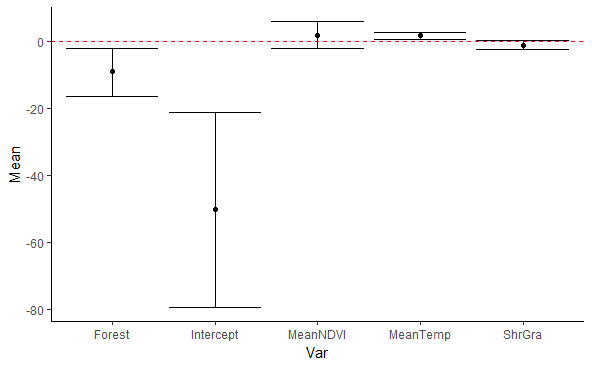

```r
coefplot.inla(I11b)
```

Wider confidence intervals - is what you would expect as you are now taking into account variance associated with distance

To consider = Did we have our range right? Should we use a finer mesh?

Lets start by looking at kappa, the estimated spatial autocorrelation

```r
SpatField.w <- inla.spde2.result(inla = I11b,
                                 name = "w",
                                 spde = spde5,
                                 do.transfer = TRUE)
Kappa <- inla.emarginal(function(x) x,
                        SpatField.w$marginals.kappa[[1]] )
Sigma.u <- inla.emarginal(function(x) sqrt(x),
                          SpatField.w$marginals.variance.nominal[[1]] )
Range <- inla.emarginal(function(x) x,
                        SpatField.w$marginals.range.nominal[[1]] )
Kappa
```

```
[1] 0.0002549428
```

```r
Sigma.u
```

```
[1] 2.208809
```

```r
Range
```

```
[1] 11094.61
```

Range estimate from our model is 11094m so 11.09 km is the range over which spatial correlation decreases. Quite different from 50km

So although there is spatial correlation it acts over quite a small distance. Maybe what we would expect for an environmental pathogen

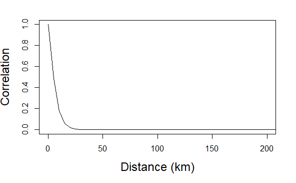

```r
#Code from Zuur et al. (2017)
LocMesh <- mesh5$loc[,1:2]
# And then we calculate the distance between each vertex.
D <- as.matrix(dist(LocMesh))
# Using the estimated parameters from the model (see above)
# we can calculate the imposed Matern correlation values.
d.vec <- seq(0, max(D), length = 100)
Cor.M <- (Kappa * d.vec) * besselK(Kappa * d.vec, 1)
Cor.M[1] <- 1
# Which we plot here:
plot(x = d.vec / 1000,
     y = Cor.M,
     pch = 16,
     type = "l",
     cex.lab = 1.5,
     xlab = "Distance (km)",
     ylab = "Correlation",
     xlim = c(0, 200))
```

Shows the distance over which correlation is occuring quite nicely. We have strong spatial correlation (over 0.1) up until around 15km after which it is fine. Suggests that BU is a localised infection

We can extract posterior distribtions for all the w’s and plot them

Inla (courtesy of code from H. Bakka and Zuur) has a way of doing this. Nb if you do the Zuur course you will see lots of more beautiful, fancy ways of doing these graphs ;)

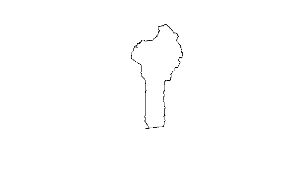

```r
Coast.Coord <- cbind(CoastPoly$x, CoastPoly$y)
Coast.Poly  <- Polygon(Coast.Coord, hole = FALSE)
CoastSP     <- SpatialPolygons(list(Polygons(list(Coast.Poly), ID = '1')))
CoastSP@proj4string  <- CRS("+proj=longlat +datum=WGS84")
plot(CoastSP)
```

```r
Coast.UTM <- spTransform(CoastSP,
                         CRS("+proj=utm +zone=31N +south ellps=WGS84 +datum=WGS84"))
#Outline of Benin in m
w.pm <- I11b$summary.random$w$mean  #extract your ws
length(w.pm)
```

```
[1] 645
```

```r
xlim<-Coast.UTM@bbox[1, ]
ylim<-Coast.UTM@bbox[2, ]
local.plot.field = function(field, mesh, xlim, ylim){
  stopifnot(length(field) == mesh$n)
  proj = inla.mesh.projector(mesh)
  field.proj = inla.mesh.project(proj, field)
  n.col = 20
  image.plot(list(x = proj$x, y=proj$y, z = field.proj),
             xlim = xlim, ylim = ylim, col = plasma(n.col), nlevel=n.col+1)
}
local.plot.field(w.pm, mesh5, xlim, ylim)
# Add the sampling locations (in UTM)
points(x = Loc[,1],
       y = Loc[,2],
       cex = 0.5,
       col = "black",
       pch = 16)
```

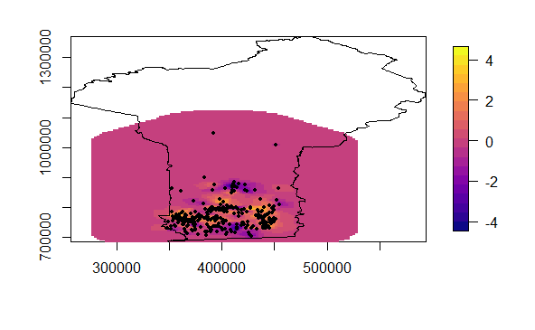

```r
# Add the coastline (in UTM)
plot(Coast.UTM , add = TRUE)
```

Are there still patterns in the residuals?

```r
xy     <- cbind(bu$X.utm, bu$Y.utm)
u.proj <- inla.mesh.projector(mesh5, loc = Loc)
u.pm   <- inla.mesh.project(u.proj, I11b$summary.random$w$mean)
# Use different font sizes and symbols dependening on the
# values of u.pm
MyCex <- 2 * abs(u.pm) / max(u.pm)
SignResidual <- as.numeric(u.pm >=0) + 1
local.plot.field(w.pm, mesh5, xlim, ylim)
points(xy,
       pch = c(16,17)[SignResidual],
       cex = MyCex)
```

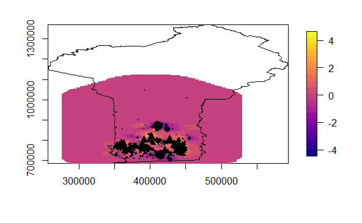

```r
# Add the coastline (in UTM)
plot(Coast.UTM , add = TRUE)
```

Still appears to be correlation in the residuals. Strong east to west gradient. Not sure what happens along here? Could be related to some kind of industry or agriculture?

Finally, what is the extent of the spatial correlation?

```r
plot(Coast.UTM, axes = TRUE)
points(x = 385000, y = 791248, col = 1, pch = 16, cex = 2)
```

```r
# How far does the correlation from this point reach?
#This could be a nice approach to look at how spatial correlation of infection probability decays from these points and compare to the spatial networks
# How many of these points are affected?
points(x = Loc[,1],
       y = Loc[,2],
       cex = 0.5,
       col = "black",
       pch = 16)
# This function is taken from:
# https://haakonbakka.bitbucket.io/btopic105.html
# We will not discuss what is in it.
local.find.correlation = function(Q, location, mesh) {
  sd = sqrt(diag(inla.qinv(Q)))
  # - the marginal standard deviations
  A.tmp = inla.spde.make.A(mesh=mesh, loc = matrix(c(location[1], location[2]),1,2))
  # - create a fake A matrix, to extract the closest mesh node index
  id.node = which.max(A.tmp[1, ])
  # - index of the closest node
  print(paste('The location used was c(',
              round(mesh$loc[id.node, 1], 4), ', ',
              round(mesh$loc[id.node, 2], 4), ')' ))
  # - location of the closest node
  # - should be close to the location input
  # - sometimes used to plot a black dot
  ## Solve a matrix system to find the column of the covariance matrix
  Inode = rep(0, dim(Q)[1]); Inode[id.node] = 1
  covar.column = solve(Q, Inode)
  corr = drop(matrix(covar.column)) / (sd*sd[id.node])
  return(corr)
}
Q <- inla.spde2.precision(spde5,
                          theta = c(log(Range ),log(Sigma.u)))
Corr <- local.find.correlation(Q,
                               loc = c(385000, 791248),
                               mesh5)
```

```
[1] "The location used was c( 383423.8731 ,  787990.3302 )"
```

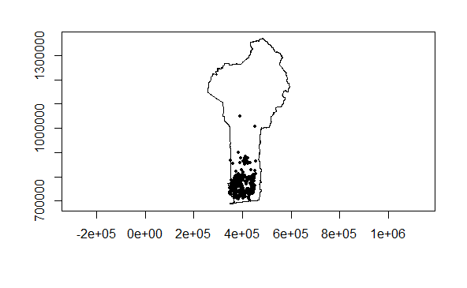

```r
#It will find the closest point on the mesh:
points(x = 479940.7739, y = 5973712.5778, col = 2, pch = 16, cex = 2)
```

```r
# And the rest is a matter of plotting
local.plot.field(Corr,mesh5, xlim, ylim )
plot(Coast.UTM, axes = TRUE, add = TRUE)
```

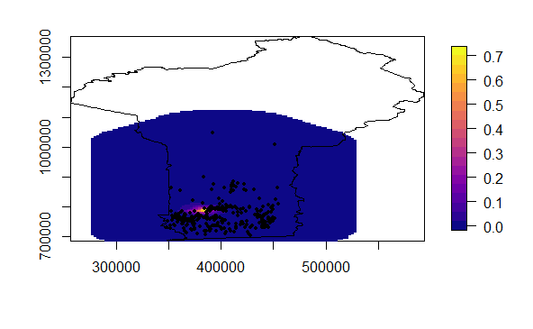

```r
points(x = Loc[,1],
       y = Loc[,2],
       cex = 0.5,
       col = "black",
       pch = 16)
```

Shows the points that are affected by the correlation from one point.

Note, we still havent checked residuals, made sure there are no patterns etc. We havent really covered this and wont have time but of course, this is a really important part of model checking.

Also, our plots are rather ugly. But there is lots of scope for improvement - eg. removing the sea etc.

Finally, just going to check the residuals to see how the spatial autocorrelation looks now

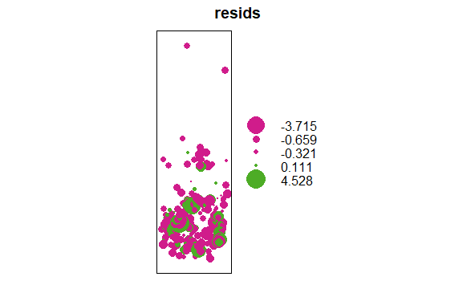

```r
Pi   <- I11b$summary.fitted.values[1:295,"mean"] #just want the fitted values for our observations
ExpY <- Pi * bu$TOT_POP
VarY <- bu$TOT_POP * Pi * (1 - Pi)
E1   <- (bu$BU_TOT - ExpY) / sqrt(VarY)
#do a bubble plot.
dat<-data.frame(bu$Long,bu$Lat,resids=E1)
coordinates(dat)<-c('bu.Long','bu.Lat')
bubble(dat,zcol='resids')
```

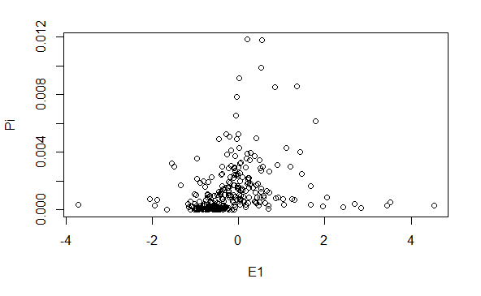

```r
#plot fitted against residuals
plot(Pi~E1)
```

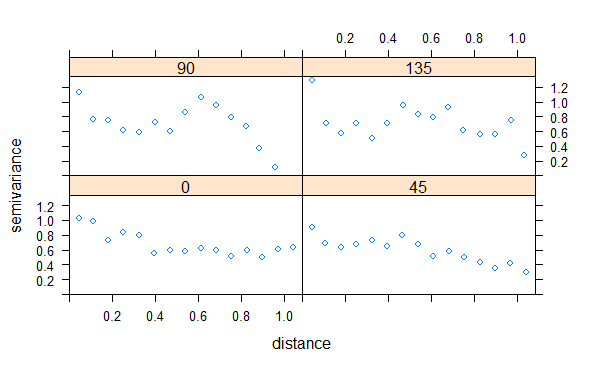

```r
#variogram
var.mod<-variogram(resids~1,data=dat,alpha=c(0,45,90,135))
plot(var.mod)
```

Its a lot better - look at the difference in the numbers. Still looks like there is something we havent dealt with however - the fitted vs residuals plot is pretty awful. Want a nice, flat plot for the variogram but it still shows some sign on east-west correlation

# Large scale autocorrelation

Matern correlation is only appropriate over short distances. However, what if we are interested in spatial correlation over larger distances as well (maybe your organism of interest moves really far)

Solution: Include long distance spatial autocorrelation as x,y coordinates as fixed effects.

To do this, we need to make a new dataframe for the stack, and include longitude and latitude as an interaction

```r
# Make the X matrix (-1 means remove the intercept)
Xm <- model.matrix(~ -1 + Forest + MeanNDVI + MeanTemp + ShrGra + Lat + Long + Lat*Long,
                   data = bu)
head(Xm)
```

```
  Forest  MeanNDVI MeanTemp ShrGra      Lat     Long Lat:Long
1   0.24 0.2209703     27.2   0.06 6.383333 2.348333 14.99019
2   0.02 0.2861486     27.2   0.65 6.818060 1.637500 11.16457
3   0.02 0.2953299     27.0   0.94 6.840560 1.670830 11.42941
4   0.00 0.2542900     26.5   0.96 6.974720 1.673890 11.67491
5   0.00 0.2868261     27.0   0.98 6.946390 1.688330 11.72780
6   0.00 0.1882990     26.7   0.99 6.947220 1.709720 11.87780
```

```r
colnames(Xm)
```

```
[1] "Forest"   "MeanNDVI" "MeanTemp" "ShrGra"   "Lat"      "Long"
[7] "Lat:Long"
```

```r
# Define sample size
N <- nrow(bu)
# This is the X matrix
X <- data.frame(Forest           = Xm[,1],
                MeanNDVI         = Xm[,2],
                MeanTemp         = Xm[,3],
                ShrGra           = Xm[,4],
                Lat              = Xm[,5],
                Long             = Xm[,6],
                Lat.Long         = Xm[,7])
head(X)
```

|  | Forest | MeanNDVI | MeanTemp | ShrGra | Lat | Long | Lat.Long |
| --- | --- | --- | --- | --- | --- | --- | --- |
| 1 | 0.24 | 0.2209703 | 27.2 | 0.06 | 6.383333 | 2.348333 | 14.99019 |
| 2 | 0.02 | 0.2861486 | 27.2 | 0.65 | 6.818060 | 1.637500 | 11.16457 |
| 3 | 0.02 | 0.2953299 | 27.0 | 0.94 | 6.840560 | 1.670830 | 11.42941 |
| 4 | 0.00 | 0.2542900 | 26.5 | 0.96 | 6.974720 | 1.673890 | 11.67491 |
| 5 | 0.00 | 0.2868261 | 27.0 | 0.98 | 6.946390 | 1.688330 | 11.72780 |
| 6 | 0.00 | 0.1882990 | 26.7 | 0.99 | 6.947220 | 1.709720 | 11.87780 |

```r
colnames(X)
```

```
[1] "Forest"   "MeanNDVI" "MeanTemp" "ShrGra"   "Lat"      "Long"
[7] "Lat.Long"
```

```r
dim(X)
```

```
[1] 295   7
```

```r
StackFit <- inla.stack(
  tag = "Fit",
  data = list(y = bu$BU_TOT, Ntrials = bu$TOT_POP),
  A = list(1, 1, A5),
  effects = list(
    Intercept = rep(1, N), #intercept included to use without covariates so can only see contribution from spatial covariates
    X = X,
    w = w5.index))
f11c <- y ~ -1 + Intercept +
  Forest  + MeanNDVI + MeanTemp +
  ShrGra + Lat*Long+
  f(w, model = spde5)
I11c <- inla(f11c,
             family = "binomial",
             data=inla.stack.data(StackFit),
             control.compute = list(dic = TRUE),
             control.predictor = list(A = inla.stack.A(StackFit)),
             Ntrials = Ntrials)
```

Interaction plot is much much slower….

Will do the residual plots and compare DICs to see whether including large scale spatial correlaton has helped

```r
SpatField.w <- inla.spde2.result(inla = I11c,
                                 name = "w",
                                 spde = spde5,
                                 do.transfer = TRUE)
Kappa <- inla.emarginal(function(x) x,
                        SpatField.w$marginals.kappa[[1]] )
Sigma.u <- inla.emarginal(function(x) sqrt(x),
                          SpatField.w$marginals.variance.nominal[[1]] )
Range <- inla.emarginal(function(x) x,
                        SpatField.w$marginals.range.nominal[[1]] )
Kappa
```

```
[1] 4.594003e-05
```

```r
Sigma.u
```

```
[1] 0.342891
```

```r
Range
```

```
[1] 61567.93
```

```r
c(I11a$dic$dic, I11b$dic$dic,I11c$dic$dic)
```

```
[1] 2615.343 1056.615 1786.304
```

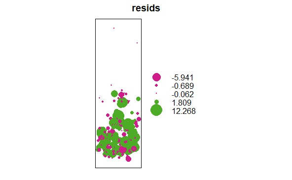

```r
Pi   <- I11c$summary.fitted.values[1:295,"mean"] #just want the fitted values for our observations
ExpY <- Pi * bu$TOT_POP
VarY <- bu$TOT_POP * Pi * (1 - Pi)
E1   <- (bu$BU_TOT - ExpY) / sqrt(VarY)
#do a bubble plot.
dat<-data.frame(bu$Long,bu$Lat,resids=E1)
coordinates(dat)<-c('bu.Long','bu.Lat')
bubble(dat,zcol='resids')
```

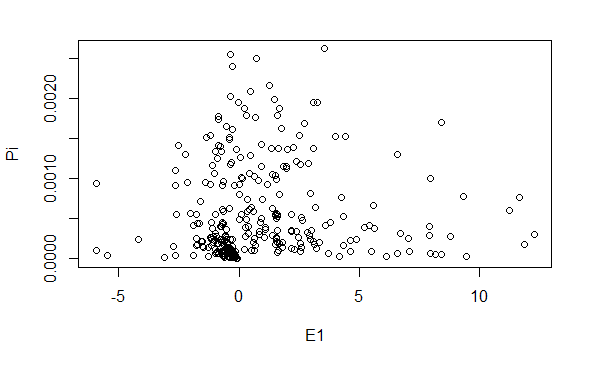

```r
#plot fitted against residuals
plot(Pi~E1)
```

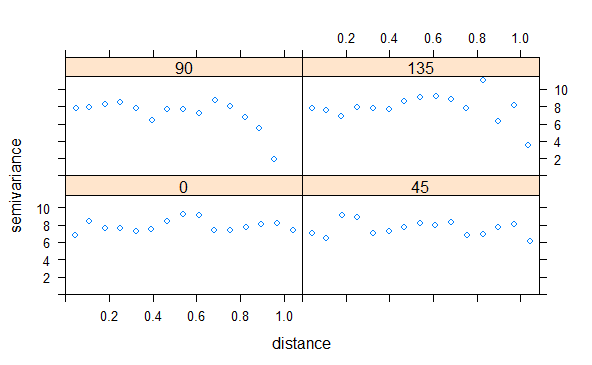

```r
#variogram
var.mod<-variogram(resids~1,data=dat,alpha=c(0,45,90,135))
plot(var.mod)
```

```r
#Outline of Benin in m
w.pm <- I11c$summary.random$w$mean  #extract your ws
length(w.pm)
```

```
[1] 645
```

```r
xlim<-Coast.UTM@bbox[1, ]
ylim<-Coast.UTM@bbox[2, ]
local.plot.field = function(field, mesh, xlim, ylim){
  stopifnot(length(field) == mesh$n)
  proj = inla.mesh.projector(mesh)
  field.proj = inla.mesh.project(proj, field)
  n.col = 20
  image.plot(list(x = proj$x, y=proj$y, z = field.proj),
             xlim = xlim, ylim = ylim, col = plasma(n.col), nlevel=n.col+1)
}
local.plot.field(w.pm, mesh5, xlim, ylim)
# Add the sampling locations (in UTM)
points(x = Loc[,1],
       y = Loc[,2],
       cex = 0.5,
       col = "black",
       pch = 16)
```

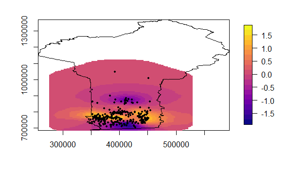

```r
# Add the coastline (in UTM)
plot(Coast.UTM , add = TRUE)
```

DIC is a lot worse, so over complicating the mdoel by adding in the large scale correlation factor didnt improve the model. Good because it took a long time! Finally, we need to interpret and predict from this model.

Interpretation: Going with model b

```r
#first extract the betas
Betas11b <- I11b$summary.fixed
print(Betas11b, digits = 2)
```

|  | mean | sd | 0.025quant | 0.5quant | 0.975quant | mode | kld |
| --- | --- | --- | --- | --- | --- | --- | --- |
| Intercept | -50.145093 | 14.7600568 | -79.3011765 | -50.088388 | -21.329707474 | -49.973293 | 1.320245e-13 |
| Forest | -9.215501 | 3.5994443 | -16.3884612 | -9.180543 | -2.242187014 | -9.110665 | 6.775819e-13 |
| MeanNDVI | 1.761867 | 2.0372716 | -2.2237123 | 1.756577 | 5.772966101 | 1.746123 | 8.730968e-14 |
| MeanTemp | 1.525087 | 0.5410252 | 0.4686465 | 1.522969 | 2.592237724 | 1.518758 | 1.342698e-13 |
| ShrGra | -1.318341 | 0.6780721 | -2.6555604 | -1.316569 | 0.007726319 | -1.313041 | 4.468350e-13 |

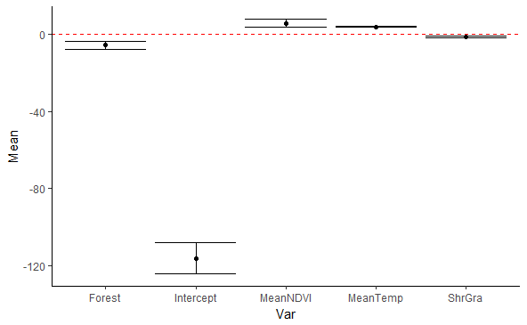

```r
#Have a think about what this means - your estimate is your slope for your betas
#####
# TASK: Write down the equation for the fitted model.
# pH_i ~ N(mu_i, sigma^2)
# NonForest:
# mu_i = 9.14 - 0.35 * Alt_i - 0.02 * SDI_i
# Forested:
# mu_i = 9.14 - 1.03 - 0.35 * Alt_i + 0.53 * Alt_i -0.02 * SDI_i
#      = 8.11 + (Something) * Alt_i - 0.02 * SDI_i
#If the model was gaussian you could extract the sigmas as below but its binomial
#
# tau <- model$marginals.hyperpar$`Precision for the Gaussian observations`
# sigma <- inla.emarginal(function(x) (1/sqrt(x)), tau)
# sigma
coefplot.inla(I11a)
```

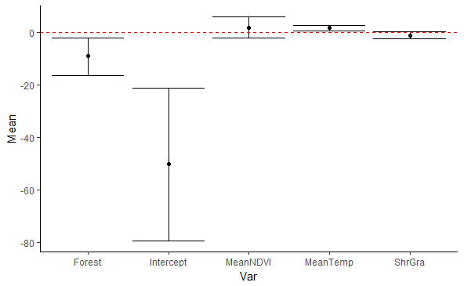

```r
coefplot.inla(I11b)
```

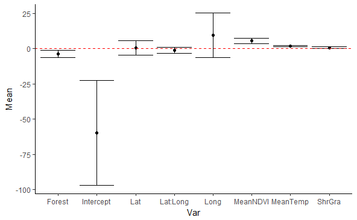

```r
coefplot.inla(I11c)
```

For prediction: Two approaches - We will use teh first method - creating a load of NA data, and predicting that.

Predict with the stack:

First we need to get the stack for original data, make a new stack which is what we want to predict, and then combine them

We need to rerun the first stack unless you didnt run the last model, so just need to create the second one

Rerun the first one below

```r
# Make the X matrix (-1 means remove the intercept)
Xm <- model.matrix(~ -1 + Forest + MeanNDVI + MeanTemp + ShrGra,
                   data = bu)
head(Xm)
```

```
  Forest  MeanNDVI MeanTemp ShrGra
1   0.24 0.2209703     27.2   0.06
2   0.02 0.2861486     27.2   0.65
3   0.02 0.2953299     27.0   0.94
4   0.00 0.2542900     26.5   0.96
5   0.00 0.2868261     27.0   0.98
6   0.00 0.1882990     26.7   0.99
```

```r
colnames(Xm)
```

```
[1] "Forest"   "MeanNDVI" "MeanTemp" "ShrGra"
```

```r
# Define sample size
N <- nrow(bu)
# This is the X matrix
X <- data.frame(Forest           = Xm[,1],
                MeanNDVI         = Xm[,2],
                MeanTemp         = Xm[,3],
                ShrGra           = Xm[,4])
head(X)
```

|  | Forest | MeanNDVI | MeanTemp | ShrGra |
| --- | --- | --- | --- | --- |
| 1 | 0.24 | 0.2209703 | 27.2 | 0.06 |
| 2 | 0.02 | 0.2861486 | 27.2 | 0.65 |
| 3 | 0.02 | 0.2953299 | 27.0 | 0.94 |
| 4 | 0.00 | 0.2542900 | 26.5 | 0.96 |
| 5 | 0.00 | 0.2868261 | 27.0 | 0.98 |
| 6 | 0.00 | 0.1882990 | 26.7 | 0.99 |

```r
colnames(X)
```

```
[1] "Forest"   "MeanNDVI" "MeanTemp" "ShrGra"
```

```r
dim(X)
```

```
[1] 295   4
```

```r
StackFit <- inla.stack(
  tag = "Fit",
  data = list(y = bu$BU_TOT, Ntrials = bu$TOT_POP),
  A = list(1, 1, A5),
  effects = list(
    Intercept = rep(1, N), #intercept included to use without covariates so can only see contribution from spatial covariates
    X = X,
    w = w5.index))
```

Now we need to make the predictive stack, whic means making the new covariates

```r
# Sketching the fitted values of the model.
newdat<-data.frame(
  Forest    = seq(min(bu$Forest), max(bu$Forest), length = 100),
  MeanNDVI       = rep(mean(bu$MeanNDVI), length = 100),
  MeanTemp  = rep(mean(bu$MeanTemp), length = 100),
  ShrGra =  rep(mean(bu$ShrGra), length = 100))
# And this is the corresponding X matrix
Xmm <- model.matrix(~ -1 + Forest + MeanNDVI + MeanTemp +
                      ShrGra,
                    data = newdat)
head(Xmm)
```

```
       Forest  MeanNDVI MeanTemp    ShrGra
1 0.000000000 0.2836233 27.37322 0.4767119
2 0.003333333 0.2836233 27.37322 0.4767119
3 0.006666667 0.2836233 27.37322 0.4767119
4 0.010000000 0.2836233 27.37322 0.4767119
5 0.013333333 0.2836233 27.37322 0.4767119
6 0.016666667 0.2836233 27.37322 0.4767119
```

```r
Xp <- data.frame(Forest       = Xmm[,1],
                 MeanNDVI          = Xmm[,2],
                 MeanTemp        = Xmm[,3],
                 ShrGra = Xmm[,4]
)
StackCov <- inla.stack(
  tag = "Covariates",
  data = list(y = NA),  #include data as an NA
  A = list(1, 1),
  effects = list(
    Intercept = rep(1, nrow(Xp)),
    Xp = Xp))
#dont include a spatial field because we want the predictions for the covariates and the intercept.  Noe that data is now NA, so INNLA will predict this
# We can combine the two stacks.
All.stacks <- inla.stack(StackFit, StackCov)
```

Now run the model with the combined stack

```r
f11p <- y ~ -1 + Intercept +
  Forest  + MeanNDVI + MeanTemp +
  ShrGra +
  f(w, model = spde5)
I11p <- inla(f11p,
             family = "binomial",
             data=inla.stack.data(All.stacks),
             control.compute = list(dic = TRUE),
             control.predictor = list(compute = TRUE,
                                      A = inla.stack.A(All.stacks)),
             Ntrials = Ntrials)
```

Now want to extract the predictions, so need to index the stacks to get the predicted data rather than the fitted data

```r
index.Fit <- inla.stack.index(All.stacks,
                              tag = "Fit")$data
index.Cov <- inla.stack.index(All.stacks,
                              tag = "Covariates")$data
#And we can extact the correct rows
I11p.fit  <- I11p$summary.fitted.values[index.Fit, c(1,3,5)]  #210  by 3
I11p.pred <- I11p$summary.fitted.values[index.Cov, c(1,3,5)]  #1250 by 3
# It is the second one we need as these are for the
# artificial covariate values.
# Add them to the MyData object.
newdat2 <- cbind(newdat, I11p.pred)
dim(newdat2)
```

```
[1] 100   7
```

```r
colnames(newdat2)
```

```
[1] "Forest"     "MeanNDVI"   "MeanTemp"   "ShrGra"     "mean"
[6] "0.025quant" "0.975quant"
```

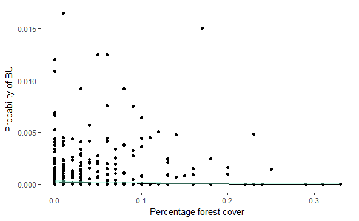

```r
#Finally, plot the predictions and the raw data
names(newdat2)[names(newdat2)=="0.975quant"] <- "Hi"
names(newdat2)[names(newdat2)=="0.025quant"] <- "Lo"
#backtransform as binomial uses the log link
#Convert logits to probability
logit2prob <- function(logit){
  odds <- exp(logit)
  prob <- odds / (1 + odds)
  return(prob)
}
newdat2$MeanE<-logit2prob(newdat2$mean); newdat2$HiE <- logit2prob(newdat2$Hi); newdat2$LoE<-logit2prob(newdat2$Lo)
#plot the predictions
ggplot()+geom_point(data=bu,aes(Forest, BU_TOT/TOT_POP))+geom_line(data = newdat2,aes(Forest, MeanE))+geom_ribbon(data = newdat2, aes(Forest, ymin =LoE,  ymax =HiE), fill = "aquamarine", alpha = 0.4)+xlab("Percentage forest cover")+ylab("Probability of BU")+theme_classic()
```

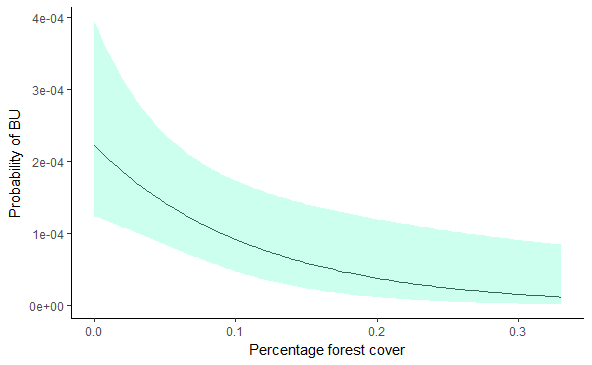

```r
ggplot()+geom_line(data = newdat2,aes(Forest, MeanE))+geom_ribbon(data = newdat2, aes(Forest, ymin =LoE,  ymax =HiE), fill = "aquamarine", alpha = 0.4)+xlab("Percentage forest cover")+ylab("Probability of BU")+theme_classic()
```

We predict a significant decrease in the probability of BU in villages with a greater proportion of forest around them. However, compared to the raw data, our model doesnt do a great job of capturing the variability (and the residuals still looked pretty bad so in real life we would not be using this model)